# Employee-Performance-Analysis

```python
import numpy as np
import pandas as pd
import seaborn as sns
import matplotlib.pyplot as plt
import warnings
warnings.filterwarnings('ignore')
```

```python
df=pd.read_csv('INX_Future_Inc_Employee.CSV')
df
```

|  | EmpNumber | Age | Gender | EducationBackground | MaritalStatus | EmpDepartment | EmpJobRole | BusinessTravelFrequency | DistanceFromHome | EmpEducationLevel | ... | EmpRelationshipSatisfaction | TotalWorkExperienceInYears | TrainingTimesLastYear | EmpWorkLifeBalance | ExperienceYearsAtThisCompany | ExperienceYearsInCurrentRole | YearsSinceLastPromotion | YearsWithCurrManager | Attrition | PerformanceRating |
| --- | --- | --- | --- | --- | --- | --- | --- | --- | --- | --- | --- | --- | --- | --- | --- | --- | --- | --- | --- | --- | --- |
| 0 | E1001000 | 32 | Male | Marketing | Single | Sales | Sales Executive | Travel_Rarely | 10 | 3 | ... | 4 | 10 | 2 | 2 | 10 | 7 | 0 | 8 | No | 3 |
| 1 | E1001006 | 47 | Male | Marketing | Single | Sales | Sales Executive | Travel_Rarely | 14 | 4 | ... | 4 | 20 | 2 | 3 | 7 | 7 | 1 | 7 | No | 3 |
| 2 | E1001007 | 40 | Male | Life Sciences | Married | Sales | Sales Executive | Travel_Frequently | 5 | 4 | ... | 3 | 20 | 2 | 3 | 18 | 13 | 1 | 12 | No | 4 |
| 3 | E1001009 | 41 | Male | Human Resources | Divorced | Human Resources | Manager | Travel_Rarely | 10 | 4 | ... | 2 | 23 | 2 | 2 | 21 | 6 | 12 | 6 | No | 3 |
| 4 | E1001010 | 60 | Male | Marketing | Single | Sales | Sales Executive | Travel_Rarely | 16 | 4 | ... | 4 | 10 | 1 | 3 | 2 | 2 | 2 | 2 | No | 3 |
| ... | ... | ... | ... | ... | ... | ... | ... | ... | ... | ... | ... | ... | ... | ... | ... | ... | ... | ... | ... | ... | ... |
| 1195 | E100992 | 27 | Female | Medical | Divorced | Sales | Sales Executive | Travel_Frequently | 3 | 1 | ... | 2 | 6 | 3 | 3 | 6 | 5 | 0 | 4 | No | 4 |
| 1196 | E100993 | 37 | Male | Life Sciences | Single | Development | Senior Developer | Travel_Rarely | 10 | 2 | ... | 1 | 4 | 2 | 3 | 1 | 0 | 0 | 0 | No | 3 |
| 1197 | E100994 | 50 | Male | Medical | Married | Development | Senior Developer | Travel_Rarely | 28 | 1 | ... | 3 | 20 | 3 | 3 | 20 | 8 | 3 | 8 | No | 3 |
| 1198 | E100995 | 34 | Female | Medical | Single | Data Science | Data Scientist | Travel_Rarely | 9 | 3 | ... | 2 | 9 | 3 | 4 | 8 | 7 | 7 | 7 | No | 3 |
| 1199 | E100998 | 24 | Female | Life Sciences | Single | Sales | Sales Executive | Travel_Rarely | 3 | 2 | ... | 1 | 4 | 3 | 3 | 2 | 2 | 2 | 0 | Yes | 2 |

1200 rows × 28 columns

# Domain Analysis

INX Future Inc. is a globally recognized analytics and automation firm. Despite its status as a top employer, the company is facing a decline in employee performance and client satisfaction.

The goal is to:

1. Identify the factors influencing employee performance
2. Build a predictive model for future employee performance (e.g., for hiring)
3. Provide data-driven recommendations to improve performance

The dataset contains 1200 records, each representing an employee.

There are 28 features (columns), including demographic info, job roles, experience, training, satisfaction scores, and finally the target: PerformanceRating.

**1. Emp Number:** Unique employee identifier (like an ID)

**2. Age:** Age of the employee (in years)

**3. Gender:** Gender of the employee (e.g., Male, Female)

**4. Education Background:** Field or domain of the employee's educational qualification (e.g., Marketing, Medical)

**5. Marital Status:** Marital status (e.g., Single, Married, Divorced)

**6. Emp Department:** Department where the employee works (e.g., Sales, Development, Human Resources)

**7. Emp Job Role:** Specific job title or role (e.g., Sales Executive, Data Scientist, Manager)

**8. Business Travel Frequency:** How often the employee travels for business (e.g., Travel_Rarely, Travel_Frequently)

**9. Distance From Home:** Distance between home and office (in kilometers or miles)

**10. Emp Education Level:** Educational level (ordinal: 1=Below College, 2=College, 3=Bachelor, 4=Master, 5=Doctorate)

**11. Emp Environment Satisfaction:** Satisfaction with work environment (scale: 1–4; 1=Low,2=Medium,3=High 4=Very High)

**12. Emp Job Satisfaction :** Satisfaction with current job role (scale: 1–4; 1=Low,2=Medium,3=High,4=Very High)

**13. Emp HourlyRate:** The employee’s hourly wage (in monetary units).

**14. Emp Job Involvement:** Degree of employee's engagement in their role (Scale: 1 = Low,2=Medium,3=High,4 = Very High). Higher involvement often correlates with better performance.

**15. Emp Job Level:** Job seniority level in the organization (e.g., 1 = Entry, 5 = Executive). Often aligns with responsibility and expected performance.

**16.Over Time:** Whether the employee works overtime (Yes or No). Can impact work-life balance and performance (either positively or negatively).

**17. Num Companies Worked:** Total number of companies the employee has previously worked for. May indicate experience or instability.

**18. Emp Last Salary Hike Percent:** Percentage increase in salary during the last hike. Can be a reward for good performance or influence motivation.

**19. Emp Relationship Satisafaction:** Satisfaction with relationships at work (scale: 1-4; 1=Low,2=Medium,3=High,4=Very High)

**20. Total Work Experience In Years:** Total years of work experience

**21. training Time Last Year:** Number of training programs attended in the last year

**22. Emp Work Life Balance:** Work-life balance rating (1=Bad, 2=Good, 3=Better, 4=Best)

**23. Experience Years At This Company:** Number of years the employee has been at INX

**24. Experience Years In Current Role:** Number of years in their current job role

**25. Years Since Last Promotion:** Number of years since the last promotion

**26. Years With Curr Manager:** Number of years under the current manager

**27. Attrition:** Whether the employee has left the company (Yes) or is still with the company (No)

**28. Performance Rating:** Employee performance rating (typically 1–4) where 1=Low,2=Good,3=Excellent,4=Outstanding

# Basic Checks

```python
df.head()
```

|  | EmpNumber | Age | Gender | EducationBackground | MaritalStatus | EmpDepartment | EmpJobRole | BusinessTravelFrequency | DistanceFromHome | EmpEducationLevel | ... | EmpRelationshipSatisfaction | TotalWorkExperienceInYears | TrainingTimesLastYear | EmpWorkLifeBalance | ExperienceYearsAtThisCompany | ExperienceYearsInCurrentRole | YearsSinceLastPromotion | YearsWithCurrManager | Attrition | PerformanceRating |
| --- | --- | --- | --- | --- | --- | --- | --- | --- | --- | --- | --- | --- | --- | --- | --- | --- | --- | --- | --- | --- | --- |
| 0 | E1001000 | 32 | Male | Marketing | Single | Sales | Sales Executive | Travel_Rarely | 10 | 3 | ... | 4 | 10 | 2 | 2 | 10 | 7 | 0 | 8 | No | 3 |
| 1 | E1001006 | 47 | Male | Marketing | Single | Sales | Sales Executive | Travel_Rarely | 14 | 4 | ... | 4 | 20 | 2 | 3 | 7 | 7 | 1 | 7 | No | 3 |
| 2 | E1001007 | 40 | Male | Life Sciences | Married | Sales | Sales Executive | Travel_Frequently | 5 | 4 | ... | 3 | 20 | 2 | 3 | 18 | 13 | 1 | 12 | No | 4 |
| 3 | E1001009 | 41 | Male | Human Resources | Divorced | Human Resources | Manager | Travel_Rarely | 10 | 4 | ... | 2 | 23 | 2 | 2 | 21 | 6 | 12 | 6 | No | 3 |
| 4 | E1001010 | 60 | Male | Marketing | Single | Sales | Sales Executive | Travel_Rarely | 16 | 4 | ... | 4 | 10 | 1 | 3 | 2 | 2 | 2 | 2 | No | 3 |

5 rows × 28 columns

```python
df.tail()
```

|  | EmpNumber | Age | Gender | EducationBackground | MaritalStatus | EmpDepartment | EmpJobRole | BusinessTravelFrequency | DistanceFromHome | EmpEducationLevel | ... | EmpRelationshipSatisfaction | TotalWorkExperienceInYears | TrainingTimesLastYear | EmpWorkLifeBalance | ExperienceYearsAtThisCompany | ExperienceYearsInCurrentRole | YearsSinceLastPromotion | YearsWithCurrManager | Attrition | PerformanceRating |
| --- | --- | --- | --- | --- | --- | --- | --- | --- | --- | --- | --- | --- | --- | --- | --- | --- | --- | --- | --- | --- | --- |
| 1195 | E100992 | 27 | Female | Medical | Divorced | Sales | Sales Executive | Travel_Frequently | 3 | 1 | ... | 2 | 6 | 3 | 3 | 6 | 5 | 0 | 4 | No | 4 |
| 1196 | E100993 | 37 | Male | Life Sciences | Single | Development | Senior Developer | Travel_Rarely | 10 | 2 | ... | 1 | 4 | 2 | 3 | 1 | 0 | 0 | 0 | No | 3 |
| 1197 | E100994 | 50 | Male | Medical | Married | Development | Senior Developer | Travel_Rarely | 28 | 1 | ... | 3 | 20 | 3 | 3 | 20 | 8 | 3 | 8 | No | 3 |
| 1198 | E100995 | 34 | Female | Medical | Single | Data Science | Data Scientist | Travel_Rarely | 9 | 3 | ... | 2 | 9 | 3 | 4 | 8 | 7 | 7 | 7 | No | 3 |
| 1199 | E100998 | 24 | Female | Life Sciences | Single | Sales | Sales Executive | Travel_Rarely | 3 | 2 | ... | 1 | 4 | 3 | 3 | 2 | 2 | 2 | 0 | Yes | 2 |

5 rows × 28 columns

```python
df.info()
```

```
<class 'pandas.core.frame.DataFrame'>
RangeIndex: 1200 entries, 0 to 1199
Data columns (total 28 columns):
 #   Column                        Non-Null Count  Dtype
---  ------                        --------------  -----
 0   EmpNumber                     1200 non-null   object
 1   Age                           1200 non-null   int64
 2   Gender                        1200 non-null   object
 3   EducationBackground           1200 non-null   object
 4   MaritalStatus                 1200 non-null   object
 5   EmpDepartment                 1200 non-null   object
 6   EmpJobRole                    1200 non-null   object
 7   BusinessTravelFrequency       1200 non-null   object
 8   DistanceFromHome              1200 non-null   int64
 9   EmpEducationLevel             1200 non-null   int64
```

[output cut: 20 more lines]

```python
df.shape
```

```
(1200, 28)
```

```python
df.describe()
```

|  | Age | DistanceFromHome | EmpEducationLevel | EmpEnvironmentSatisfaction | EmpHourlyRate | EmpJobInvolvement | EmpJobLevel | EmpJobSatisfaction | NumCompaniesWorked | EmpLastSalaryHikePercent | EmpRelationshipSatisfaction | TotalWorkExperienceInYears | TrainingTimesLastYear | EmpWorkLifeBalance | ExperienceYearsAtThisCompany | ExperienceYearsInCurrentRole | YearsSinceLastPromotion | YearsWithCurrManager | PerformanceRating |
| --- | --- | --- | --- | --- | --- | --- | --- | --- | --- | --- | --- | --- | --- | --- | --- | --- | --- | --- | --- |
| count | 1200.000000 | 1200.000000 | 1200.00000 | 1200.000000 | 1200.000000 | 1200.000000 | 1200.000000 | 1200.000000 | 1200.000000 | 1200.000000 | 1200.000000 | 1200.000000 | 1200.000000 | 1200.000000 | 1200.000000 | 1200.000000 | 1200.000000 | 1200.000000 | 1200.000000 |
| mean | 36.918333 | 9.165833 | 2.89250 | 2.715833 | 65.981667 | 2.731667 | 2.067500 | 2.732500 | 2.665000 | 15.222500 | 2.725000 | 11.330000 | 2.785833 | 2.744167 | 7.077500 | 4.291667 | 2.194167 | 4.105000 | 2.948333 |
| std | 9.087289 | 8.176636 | 1.04412 | 1.090599 | 20.211302 | 0.707164 | 1.107836 | 1.100888 | 2.469384 | 3.625918 | 1.075642 | 7.797228 | 1.263446 | 0.699374 | 6.236899 | 3.613744 | 3.221560 | 3.541576 | 0.518866 |
| min | 18.000000 | 1.000000 | 1.00000 | 1.000000 | 30.000000 | 1.000000 | 1.000000 | 1.000000 | 0.000000 | 11.000000 | 1.000000 | 0.000000 | 0.000000 | 1.000000 | 0.000000 | 0.000000 | 0.000000 | 0.000000 | 2.000000 |
| 25% | 30.000000 | 2.000000 | 2.00000 | 2.000000 | 48.000000 | 2.000000 | 1.000000 | 2.000000 | 1.000000 | 12.000000 | 2.000000 | 6.000000 | 2.000000 | 2.000000 | 3.000000 | 2.000000 | 0.000000 | 2.000000 | 3.000000 |
| 50% | 36.000000 | 7.000000 | 3.00000 | 3.000000 | 66.000000 | 3.000000 | 2.000000 | 3.000000 | 2.000000 | 14.000000 | 3.000000 | 10.000000 | 3.000000 | 3.000000 | 5.000000 | 3.000000 | 1.000000 | 3.000000 | 3.000000 |
| 75% | 43.000000 | 14.000000 | 4.00000 | 4.000000 | 83.000000 | 3.000000 | 3.000000 | 4.000000 | 4.000000 | 18.000000 | 4.000000 | 15.000000 | 3.000000 | 3.000000 | 10.000000 | 7.000000 | 3.000000 | 7.000000 | 3.000000 |
| max | 60.000000 | 29.000000 | 5.00000 | 4.000000 | 100.000000 | 4.000000 | 5.000000 | 4.000000 | 9.000000 | 25.000000 | 4.000000 | 40.000000 | 6.000000 | 4.000000 | 40.000000 | 18.000000 | 15.000000 | 17.000000 | 4.000000 |

```python
df.describe(include='O')
```

|  | EmpNumber | Gender | EducationBackground | MaritalStatus | EmpDepartment | EmpJobRole | BusinessTravelFrequency | OverTime | Attrition |
| --- | --- | --- | --- | --- | --- | --- | --- | --- | --- |
| count | 1200 | 1200 | 1200 | 1200 | 1200 | 1200 | 1200 | 1200 | 1200 |
| unique | 1200 | 2 | 6 | 3 | 6 | 19 | 3 | 2 | 2 |
| top | E1001000 | Male | Life Sciences | Married | Sales | Sales Executive | Travel_Rarely | No | No |
| freq | 1 | 725 | 492 | 548 | 373 | 270 | 846 | 847 | 1022 |

```python
df['EmpDepartment'].unique()
```

```
array(['Sales', 'Human Resources', 'Development', 'Data Science',
       'Research & Development', 'Finance'], dtype=object)
```

```python
df['MaritalStatus'].unique()
```

```
array(['Single', 'Married', 'Divorced'], dtype=object)
```

```python
df['EmpJobRole'].unique()
```

```
array(['Sales Executive', 'Manager', 'Developer', 'Sales Representative',
       'Human Resources', 'Senior Developer', 'Data Scientist',
       'Senior Manager R&D', 'Laboratory Technician',
       'Manufacturing Director', 'Research Scientist',
       'Healthcare Representative', 'Research Director', 'Manager R&D',
       'Finance Manager', 'Technical Architect', 'Business Analyst',
       'Technical Lead', 'Delivery Manager'], dtype=object)
```

```python
df['Attrition'].unique()
```

```
array(['No', 'Yes'], dtype=object)
```

```python
df['EducationBackground'].unique()
```

```
array(['Marketing', 'Life Sciences', 'Human Resources', 'Medical',
       'Other', 'Technical Degree'], dtype=object)
```

```python
df['BusinessTravelFrequency'].unique()
```

```
array(['Travel_Rarely', 'Travel_Frequently', 'Non-Travel'], dtype=object)
```

```python
df['OverTime'].unique()
```

```
array(['No', 'Yes'], dtype=object)
```

# Exploratory Data Analysis (EDA)

### Univariate Analysis

#### Categorical Feature Distributions

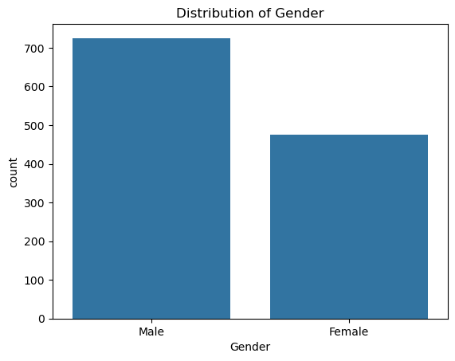

```python
sns.countplot(x=df.Gender)
plt.title('Distribution of Gender')
plt.show()
```

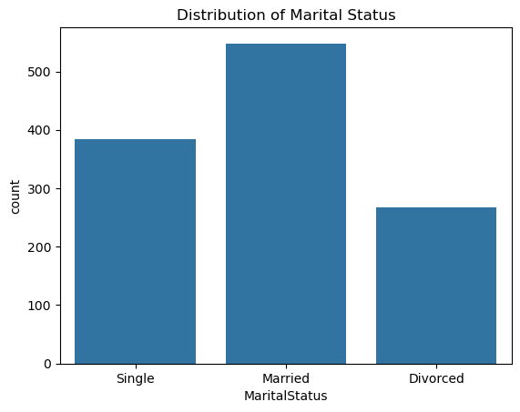

```python
sns.countplot(x=df.MaritalStatus)
plt.title('Distribution of Marital Status')
plt.show()
```

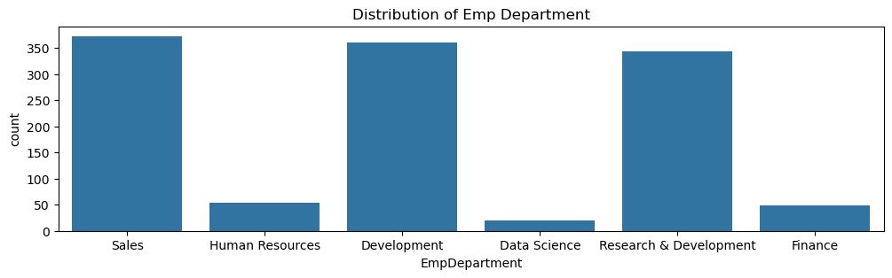

```python
plt.figure(figsize=(12,3))
sns.countplot(x=df.EmpDepartment)
plt.title('Distribution of Emp Department')
plt.show()
```

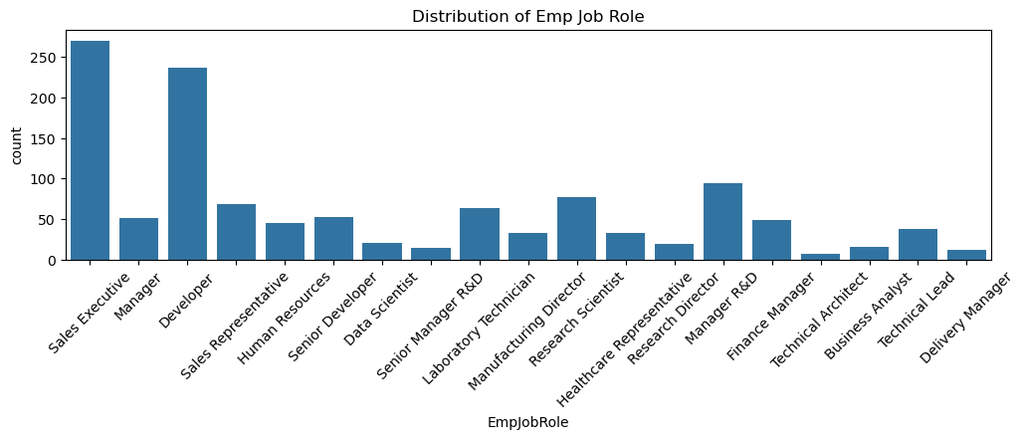

```python
plt.figure(figsize=(12,3))
sns.countplot(x=df.EmpJobRole)
plt.title('Distribution of Emp Job Role')
plt.xticks(rotation=45)
plt.show()
```

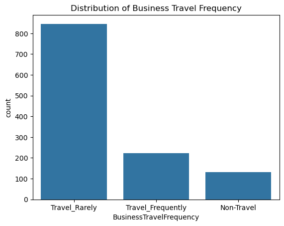

```python
sns.countplot(x=df.BusinessTravelFrequency)
plt.title('Distribution of Business Travel Frequency')
plt.show()
```

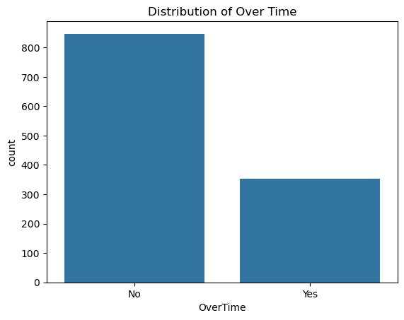

```python
sns.countplot(x=df.OverTime)
plt.title('Distribution of Over Time')
plt.show()
```

#### INSIGHTS:

**1. Gender**

- Distribution is likely imbalanced, with more male employees than female.
- This may or may not influence performance directly.

**2. Marital Status**

- Most of the employees are married.
- Divorced being a minority class.
- Single employees might have higher flexibility for travel or overtime, but not necessarily higher performance.

**3. Emp Department**

- Sales, Developemnt, Research & Development departments likely has the largest employee base.
- Some department are showing lower average performance rating.

**4. Emp Job Role**

- Sales Executive appears very frequently, possibly dominating the workforce.
- Roles like Manager, Data Scientist, and Senior Developer might be fewer but hold higher responsibility.

**5. Business Travel Frequency**

- Most employees likely travel rarely, with fewer in frequent travel.
- Frequent travel could relate to burnout or reduced job satisfaction, depending on support.
- Frequent travel could impact satisfaction or performance.

**6. OverTime**

- Majority of employees do not work overtime.
- Roughly 25–30% of employees work overtime.
- Overtime could signal dedication, but might also lead to burnout or lower job satisfaction over time.

#### Numerical Feature Distributions

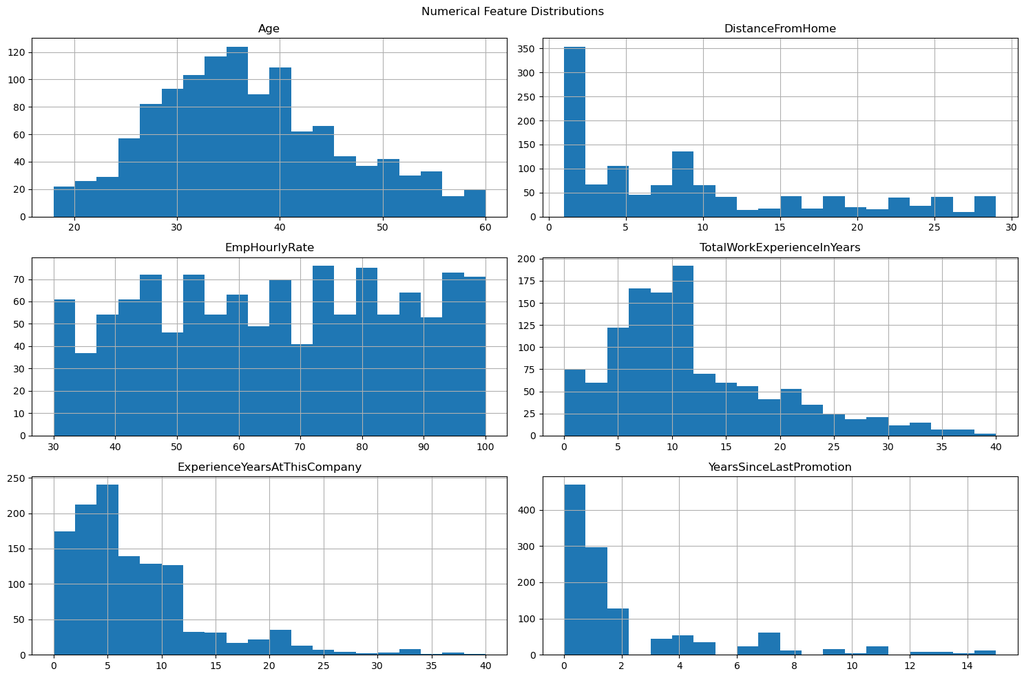

```python
numerical_cols = ['Age', 'DistanceFromHome', 'EmpHourlyRate', 'TotalWorkExperienceInYears',
                  'ExperienceYearsAtThisCompany', 'YearsSinceLastPromotion']

df[numerical_cols].hist(bins=20,figsize=(15, 10),layout=(3,2))
plt.suptitle('Numerical Feature Distributions')
plt.tight_layout()
plt.show()
```

#### INSIGHTS:

**1. Age**

- Most employees fall between 30 and 40 years.
- Distribution is close to normal, slightly right-skewed.

**2. Distance Frome Home**

- Fairly uniform distribution between 30 and 100.
- No strong peaks—suggests a balanced pay structure.

**4. Total Work Experience in Years**

- Right-skewed: Majority have 5–15 years of experience.
- A few employees have 30+ years, but these are outliers.
- Suggests mid-level professionals dominate, with few freshers.

**5. Experience Years at this Company**

- Strong right-skew: Most employees have been at INX for <10 years, peaking at 3–5 years.
- Few employees have very long tenures (>20 years).

**6. Years Since Last Promotion**

- Majority have 0–2 years since last promotion.
- A long tail of employees who haven’t been promoted in 6+ years.

### Bivariate Analysis

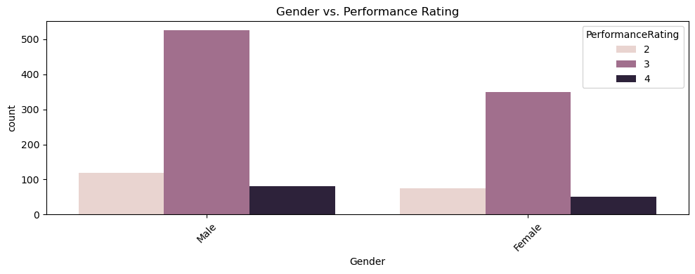

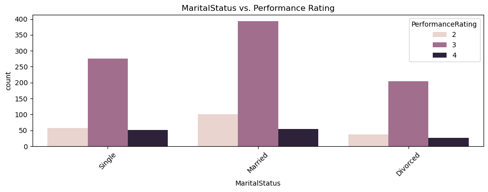

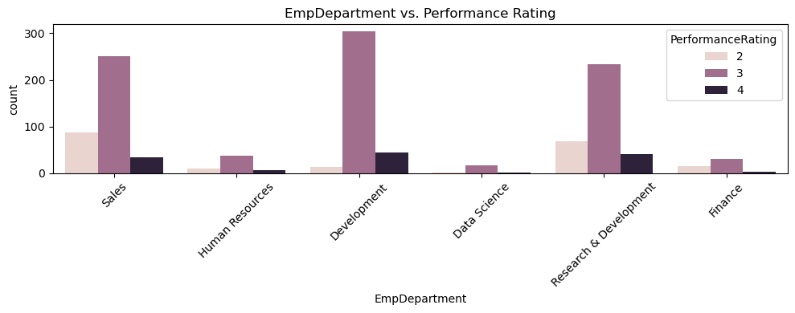

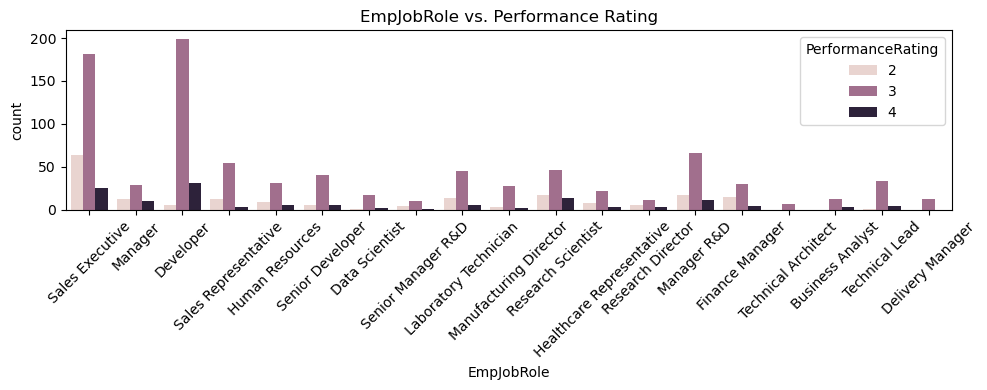

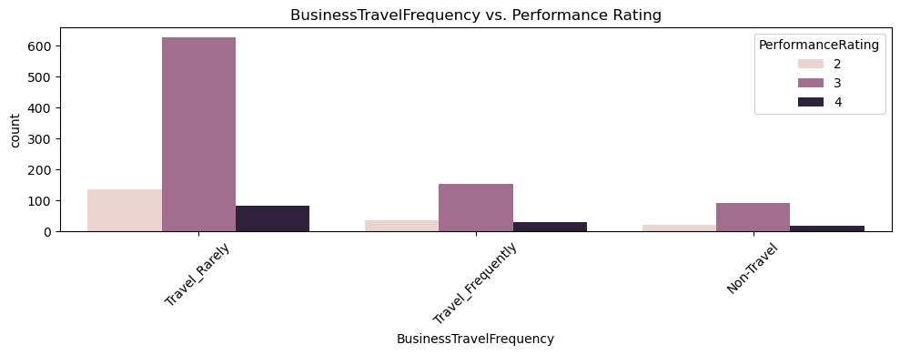

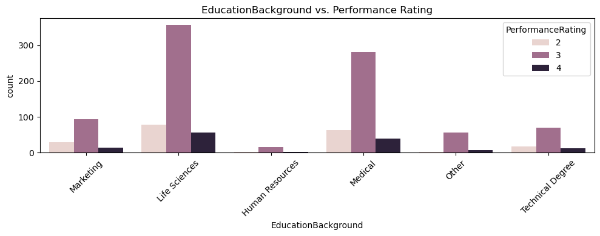

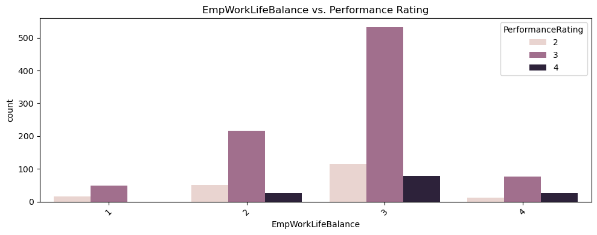

```python
categorical_cols = ['Gender', 'MaritalStatus', 'EmpDepartment', 'EmpJobRole',
                    'BusinessTravelFrequency', 'EducationBackground', 'EmpWorkLifeBalance']

for col in categorical_cols:
    plt.figure(figsize=(10,4))
    sns.countplot(data=df, x=col, hue='PerformanceRating')
    plt.title(f'{col} vs. Performance Rating')
    plt.xticks(rotation=45)
    plt.tight_layout()
    plt.show()
```

#### INSIGHTS:

**1. Gender vs. Performance Rating**

- If both males and females have similar distributions across all performance ratings → no significant gender-based performance difference.
- If one gender is underrepresented in higher ratings → may indicate bias or role-based imbalance.

**2. Marital Status vs. Performance Rating**

- Married employees might show higher stability and performance in some organizations.
- If single/divorced employees dominate lower ratings → could indicate work-life challenges, especially if linked to long hours or traveL.

**3. EmpDepartment vs. Performance Rating**

- Certain departments may have higher proportions of top performers due to technical roles with clear KPIs.
- Others might show more mid-level performance, possibly due to subjective evaluations.

**4. EmpJobRole vs. Performance Rating**

- Sales Executives or entry-level roles might show a wider spread, with more average ratings.

**5. BusinessTravelFrequency vs. Performance Rating**

- Employees who Travel Frequently may either perform higher (client-facing roles) or lower (burnout/fatigue).
- If Travel_Rarely employees have more top ratings, travel could be impacting productivity.

**6. EducationBackground vs. Performance Rating**

- Higher education levels (e.g. Medical, Life Sciences) might correlate with better ratings, depending on the role.
- If Marketing or Humanities backgrounds show lower ratings in technical roles, this may reflect skill mismatch rather than capability.

**7. EmpWorkLifeBalance vs. Performance Rating**

- If employees with poor work-life balance consistently score high, this might indicate overworking or burnout risk.
- If those with excellent balance have higher ratings → healthy workplace culture.

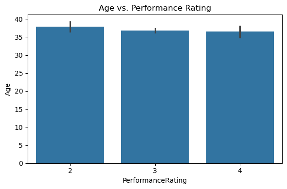

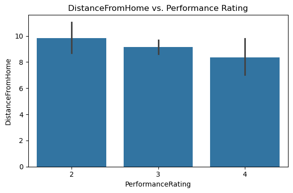

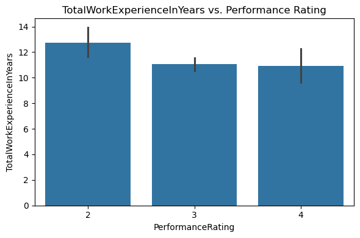

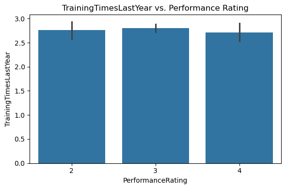

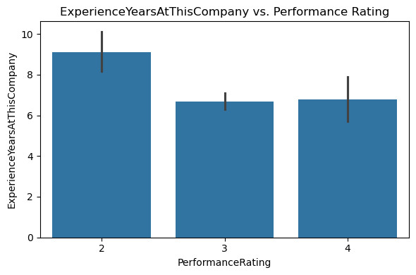

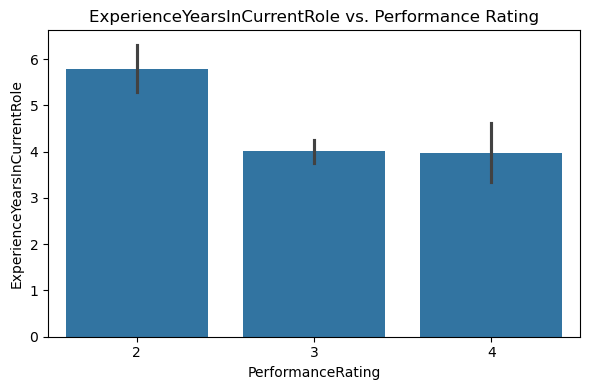

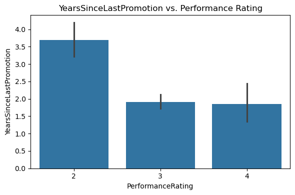

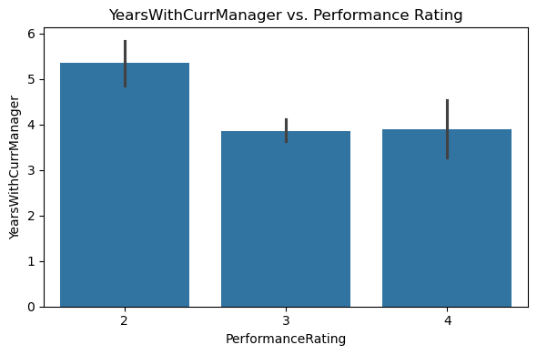

```python
numerical_cols = ['Age', 'DistanceFromHome', 'TotalWorkExperienceInYears',
                  'TrainingTimesLastYear', 'ExperienceYearsAtThisCompany',
                  'ExperienceYearsInCurrentRole', 'YearsSinceLastPromotion',
                  'YearsWithCurrManager']

for col in numerical_cols:
    plt.figure(figsize=(6,4))
    sns.barplot(data=df, x='PerformanceRating', y=col)
    plt.title(f'{col} vs. Performance Rating')
    plt.tight_layout()
    plt.show()
```

# Data Preprocessing

```python
df
```

|  | EmpNumber | Age | Gender | EducationBackground | MaritalStatus | EmpDepartment | EmpJobRole | BusinessTravelFrequency | DistanceFromHome | EmpEducationLevel | ... | EmpRelationshipSatisfaction | TotalWorkExperienceInYears | TrainingTimesLastYear | EmpWorkLifeBalance | ExperienceYearsAtThisCompany | ExperienceYearsInCurrentRole | YearsSinceLastPromotion | YearsWithCurrManager | Attrition | PerformanceRating |
| --- | --- | --- | --- | --- | --- | --- | --- | --- | --- | --- | --- | --- | --- | --- | --- | --- | --- | --- | --- | --- | --- |
| 0 | E1001000 | 32 | Male | Marketing | Single | Sales | Sales Executive | Travel_Rarely | 10 | 3 | ... | 4 | 10 | 2 | 2 | 10 | 7 | 0 | 8 | No | 3 |
| 1 | E1001006 | 47 | Male | Marketing | Single | Sales | Sales Executive | Travel_Rarely | 14 | 4 | ... | 4 | 20 | 2 | 3 | 7 | 7 | 1 | 7 | No | 3 |
| 2 | E1001007 | 40 | Male | Life Sciences | Married | Sales | Sales Executive | Travel_Frequently | 5 | 4 | ... | 3 | 20 | 2 | 3 | 18 | 13 | 1 | 12 | No | 4 |
| 3 | E1001009 | 41 | Male | Human Resources | Divorced | Human Resources | Manager | Travel_Rarely | 10 | 4 | ... | 2 | 23 | 2 | 2 | 21 | 6 | 12 | 6 | No | 3 |
| 4 | E1001010 | 60 | Male | Marketing | Single | Sales | Sales Executive | Travel_Rarely | 16 | 4 | ... | 4 | 10 | 1 | 3 | 2 | 2 | 2 | 2 | No | 3 |
| ... | ... | ... | ... | ... | ... | ... | ... | ... | ... | ... | ... | ... | ... | ... | ... | ... | ... | ... | ... | ... | ... |
| 1195 | E100992 | 27 | Female | Medical | Divorced | Sales | Sales Executive | Travel_Frequently | 3 | 1 | ... | 2 | 6 | 3 | 3 | 6 | 5 | 0 | 4 | No | 4 |
| 1196 | E100993 | 37 | Male | Life Sciences | Single | Development | Senior Developer | Travel_Rarely | 10 | 2 | ... | 1 | 4 | 2 | 3 | 1 | 0 | 0 | 0 | No | 3 |
| 1197 | E100994 | 50 | Male | Medical | Married | Development | Senior Developer | Travel_Rarely | 28 | 1 | ... | 3 | 20 | 3 | 3 | 20 | 8 | 3 | 8 | No | 3 |
| 1198 | E100995 | 34 | Female | Medical | Single | Data Science | Data Scientist | Travel_Rarely | 9 | 3 | ... | 2 | 9 | 3 | 4 | 8 | 7 | 7 | 7 | No | 3 |
| 1199 | E100998 | 24 | Female | Life Sciences | Single | Sales | Sales Executive | Travel_Rarely | 3 | 2 | ... | 1 | 4 | 3 | 3 | 2 | 2 | 2 | 0 | Yes | 2 |

1200 rows × 28 columns

```python
# checking for missing values
df.isnull().sum()
```

```
EmpNumber                       0
Age                             0
Gender                          0
EducationBackground             0
MaritalStatus                   0
EmpDepartment                   0
EmpJobRole                      0
BusinessTravelFrequency         0
DistanceFromHome                0
EmpEducationLevel               0
EmpEnvironmentSatisfaction      0
EmpHourlyRate                   0
EmpJobInvolvement               0
EmpJobLevel                     0
EmpJobSatisfaction              0
NumCompaniesWorked              0
OverTime                        0
EmpLastSalaryHikePercent        0
EmpRelationshipSatisfaction     0
TotalWorkExperienceInYears      0
TrainingTimesLastYear           0
EmpWorkLifeBalance              0
ExperienceYearsAtThisCompany    0
ExperienceYearsInCurrentRole    0
YearsSinceLastPromotion         0
YearsWithCurrManager            0
Attrition                       0
PerformanceRating               0
dtype: int64
```

```python
# There is no missing values
```

```python
# Checking for duplicates
df.duplicated().sum()
```

```
0
```

```python
# There is no duplicates
```